# Final Project: R Reference

Jahiya Clark

12/2/2021

# Part 1: R Reference Guide

## Loading Data Packages

```r
require(here)
library(palmerpenguins)
ginkgo <- data.frame(read.csv(here("data", "ginkgo_data_2021.csv")))
head(ginkgo)
```

```
##   ï..site_id seeds_present max_width max_depth notch_depth petiole_length
## 1       7719         FALSE        71        40           0             30
## 2       7719         FALSE        64        38           0             23
## 3       7719         FALSE        55        32           0             20
## 4       7719         FALSE        62        40           0             28
## 5       7719         FALSE        65        40           0             25
## 6       7719         FALSE        70        50           0             55
```

## Data Structures

### c()

The function c() combines or concatenates its arguments into a vector (a 1-dimensional data structure consisting of 1 or more elements).

- All of the elements must be of the same type.
  - I can’t combine character and numeric types in the same call to c() Here’s two examples using numeric and character data types:

```r
## Create a vector of numbers:
num_vec  = c(1, 4, 8, 9, 13)

## Create a vector of characters:
char_vec = c("a", "fish", "data is cool")

## Typing the name of the vector into the console prints the contents
num_vec
```

```
## [1]  1  4  8  9 13
```

```r
## The print() function accomplishes the same task:
print(char_vec)
```

```
## [1] "a"            "fish"         "data is cool"
```

### length()

The function length() can be used to get the length of vectors (including lists) and factors.

```r
length(ginkgo$ï..site_id)
```

```
## [1] 756
```

### Matrix()

This function creates matrix from given data values.

```r
matrix(data = 0:50, nrow = 5, ncol = 5, byrow = FALSE)
```

```
##      [,1] [,2] [,3] [,4] [,5]
## [1,]    0    5   10   15   20
## [2,]    1    6   11   16   21
## [3,]    2    7   12   17   22
## [4,]    3    8   13   18   23
## [5,]    4    9   14   19   24
```

### Data.Frame()

The function data frame() creates a collection of variables related to each other in matrices and lists.

```r
head(data.frame(ginkgo))
```

```
##   ï..site_id seeds_present max_width max_depth notch_depth petiole_length
## 1       7719         FALSE        71        40           0             30
## 2       7719         FALSE        64        38           0             23
## 3       7719         FALSE        55        32           0             20
## 4       7719         FALSE        62        40           0             28
## 5       7719         FALSE        65        40           0             25
## 6       7719         FALSE        70        50           0             55
```

```r
nrow(ginkgo)
```

```
## [1] 756
```

```r
ncol(ginkgo)
```

```
## [1] 6
```

```r
dim(ginkgo)
```

```
## [1] 756   6
```

## Subsetting

### $

```r
head(ginkgo$seeds_present)
```

```
## [1] FALSE FALSE FALSE FALSE FALSE FALSE
```

### []

```r
ginkgo[1,]
```

```
##   ï..site_id seeds_present max_width max_depth notch_depth petiole_length
## 1       7719         FALSE        71        40           0             30
```

```r
ginkgo[2,3]
```

```
## [1] 64
```

```r
head(ginkgo[,3])
```

```
## [1] 71 64 55 62 65 70
```

### Subset()

```r
head(subset(penguins, species == "Adelie"))
```

```
##   species    island bill_length_mm bill_depth_mm flipper_length_mm body_mass_g
## 1  Adelie Torgersen           39.1          18.7               181        3750
## 2  Adelie Torgersen           39.5          17.4               186        3800
## 3  Adelie Torgersen           40.3          18.0               195        3250
## 4  Adelie Torgersen             NA            NA                NA          NA
## 5  Adelie Torgersen           36.7          19.3               193        3450
## 6  Adelie Torgersen           39.3          20.6               190        3650
##      sex year
## 1   male 2007
## 2 female 2007
## 3 female 2007
## 4   <NA> 2007
## 5 female 2007
## 6   male 2007
```

## Numerical Data Exploration

### Summary()

The function summary() is used to produce result summaries of the results of various model fitting functions.

```r
summary(ginkgo)
```

```
##    ï..site_id    seeds_present     max_width        max_depth
##  Min.   : 1896   Mode :logical   Min.   : 16.00   Min.   : 19.00
##  1st Qu.: 3703   FALSE:636       1st Qu.: 63.00   1st Qu.: 43.00
##  Median : 6066   TRUE :120       Median : 74.00   Median : 51.00
##  Mean   : 6079                   Mean   : 74.34   Mean   : 58.51
##  3rd Qu.: 7206                   3rd Qu.: 85.00   3rd Qu.: 66.00
##  Max.   :12982                   Max.   :130.00   Max.   :145.00
##
##   notch_depth    petiole_length
##  Min.   : 0.00   Min.   :  8.00
##  1st Qu.: 0.00   1st Qu.: 34.00
##  Median : 0.00   Median : 47.00
##  Mean   : 2.99   Mean   : 48.25
##  3rd Qu.: 4.00   3rd Qu.: 60.00
##  Max.   :49.00   Max.   :113.00
##                  NA's   :4
```

### Mean()

The function mean() is used to get the result of the data’s arithmetic mean.

```r
mean(ginkgo$max_width)
```

```
## [1] 74.33823
```

### SD()

The function sd() is used to get the standard deviation of the interested data.

```r
sd(ginkgo$max_width)
```

```
## [1] 16.4203
```

## Graphical Data Exploration

### Scatterplot

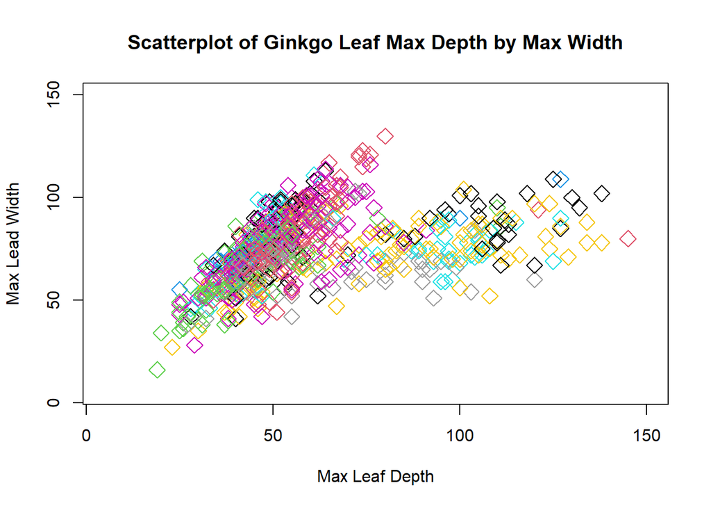

```r
plot(max_width ~ max_depth, data = ginkgo,
     xlab = "Max Leaf Depth", ylab = "Max Lead Width",
     main = "Scatterplot of Ginkgo Leaf Max Depth by Max Width",
     col = ginkgo$ï..site_id, xlim = c(5, 150), ylim = c(5, 150), pch= 5, cex = 1.5)
```

### Histogram

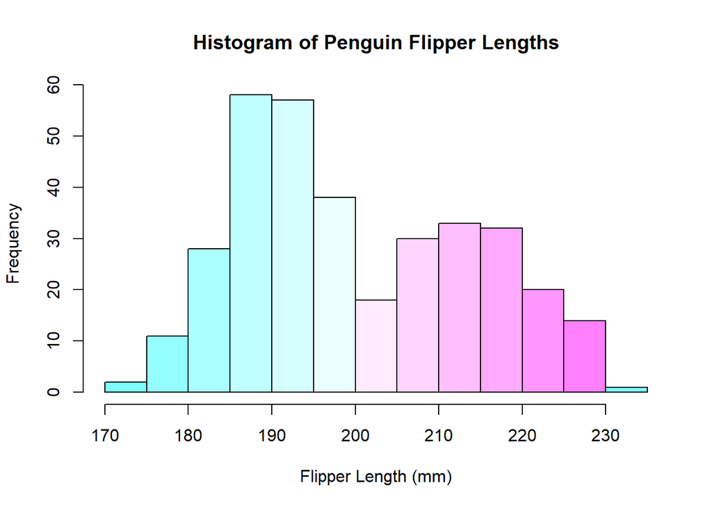

```r
require(palmerpenguins)
penguins <- data.frame(penguins)

hist(penguins$flipper_length_mm, breaks = 12, main = "Histogram of Penguin Flipper Lengths", xlab = "Flipper Length (mm)", col = cm.colors(12))
```

### Boxplot

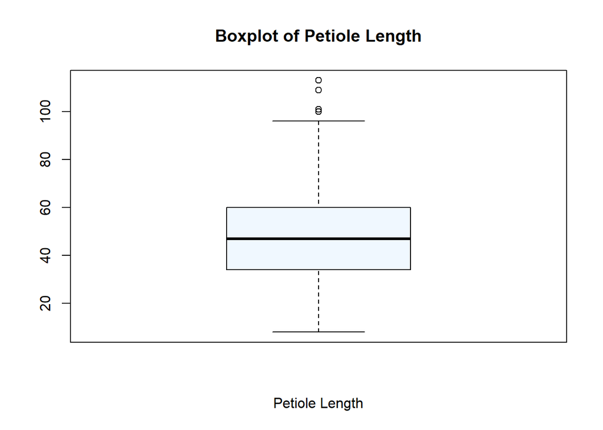

```r
boxplot(ginkgo$petiole_length, xlab = "Petiole Length", main = "Boxplot of Petiole Length", col = "aliceblue")
```

[figure not shown]

```r
boxplot(ginkgo$seeds_present, ginkgo$max_depth, names = c("No Seeds", "Seed Present"), main = "Boxplot of Seed Presence
        by the Max Leaf Depth", col = topo.colors(2))
```

### Par() and Mrow of Histograms

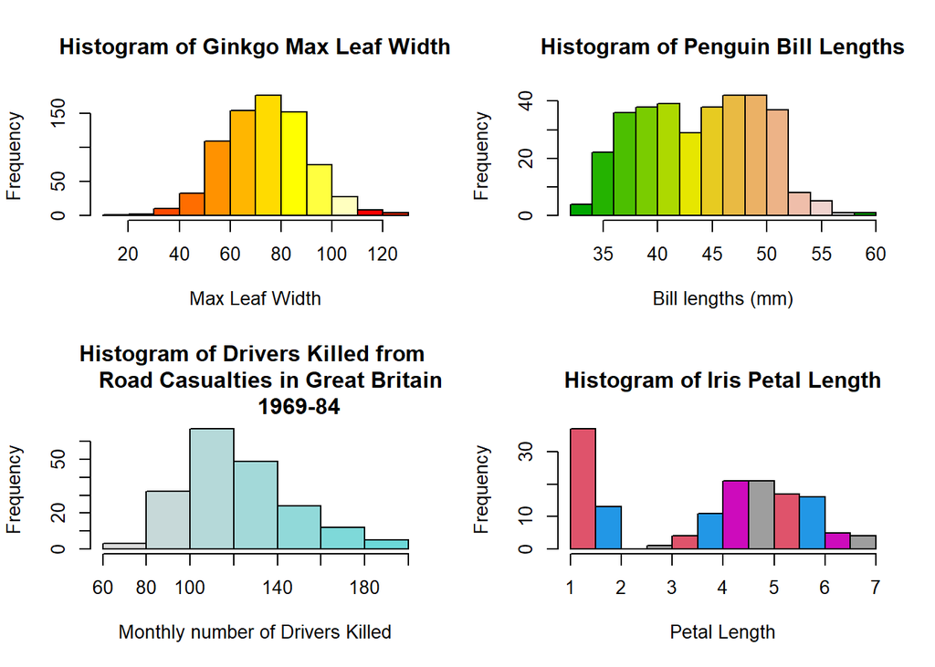

```r
par(mfrow = c(2, 2))

hist(ginkgo$max_width, main = "Histogram of Ginkgo Max Leaf Width", xlab = "Max Leaf Width", col = heat.colors(10))
hist(penguins$bill_length_mm, main = "Histogram of Penguin Bill Lengths", xlab = "Bill lengths (mm)", col= terrain.colors(13))

seat <- data.frame(Seatbelts)
hist(seat$DriversKilled, main = "Histogram of Drivers Killed from
     Road Casualties in Great Britain
              1969-84", xlab = "Monthly number of Drivers Killed",
    col =hsv(0.5, seq(0,.50,length.out = 7), .85) )
hist(iris$Petal.Length, main = "Histogram of Iris Petal Length", xlab = "Petal Length", col=c(2,4,6,8))
```

## Distribution Functions

### dnorm()

dnorm() calculates the probability density of normal distribution.

```r
dnorm(x = -8:8, mean = 1, sd = 3)
```

```
##  [1] 0.001477283 0.003798662 0.008740630 0.017996989 0.033159046 0.054670025
##  [7] 0.080656908 0.106482669 0.125794409 0.132980760 0.125794409 0.106482669
## [13] 0.080656908 0.054670025 0.033159046 0.017996989 0.008740630
```

### pnorm()

pnorm outputs the cumulative distribution of the normal distribution.

```r
pnorm(0, mean = 0, sd = 1)
```

```
## [1] 0.5
```

### qnorm()

qnorm outputs the quantile Q for any probability.

```r
qnorm(0.17, mean = 0, sd = 1)
```

```
## [1] -0.9541653
```

### dbinom()

dbinom() calculates the probability density of binomial distribution

```r
dbinom(x = 1:10, size = 10, prob = 0.4)
```

```
##  [1] 0.0403107840 0.1209323520 0.2149908480 0.2508226560 0.2006581248
##  [6] 0.1114767360 0.0424673280 0.0106168320 0.0015728640 0.0001048576
```

### pbinom()

pbinom will give you the binomial distribution of an event.

```r
pbinom(69, size = 10, prob = 0.3)
```

```
## [1] 1
```

### qbinom()

qbinom will output the binomial quantile function.

```r
qbinom(p = 0.67, size = 5, prob = 0.47)
```

```
## [1] 3
```